# Bajram_Ajdini_me1701_code

### ΠΑΝΕΠΙΣΤΗΜΙΟ ΠΕΙΡΑΙΩΣ – ΤΜΗΜΑ ΨΗΦΙΑΚΩΝ ΣΥΣΤΗΜΑΤΩΝ ΠΡΟΓΡΑΜΜΑ ΜΕΤΑΠΤΥΧΙΑΚΩΝ ΣΠΟΥΔΩΝ “Ψηφιακά Συστήματα και Υπηρεσίες” Κατεύθυνση: Μεγάλα Δεδομένα και Αναλυτική Μεγάλα Δεδομένα και Αναλυτική II: Τεχνικές και Εργαλεία

### Μεγάλα Δεδομένα και Αναλυτική II: Τεχνικές και Εργαλεία Απαλλακτική Εργασία Εξαμήνου κ. Χ. Δουλκερίδη - κα Α. Βλάχου

### Όνοματεπώνυμο: Μπαϊράμ Αϊντίνι ΑΜ: ΜΕ 1701

## Μέρος 1

## Περιγραφή των δεδομένων

## Εισαγωγή των βιβλιοθηκών

- Εισάγουμε τις βιβλιοθήκες όπου θα χρειαστούμε στη συνεχεία για την υλοποίηση της εργασίας

```python
import os.path
import matplotlib.pyplot as plt
import matplotlib
matplotlib.style.use('ggplot')
matplotlib.rcParams['figure.figsize'] = (16, 20)
import pyspark.sql.functions as func
import geopandas as gpd
import pandas as pd
from pandas import Series
from geopandas import GeoDataFrame
from pyspark import SparkContext,SparkConf
from pyspark.sql import SparkSession
from pyspark.sql import functions as f
from pyspark.sql import types as t
from descartes import PolygonPatch
from matplotlib.patches import Polygon
from matplotlib.collections import PatchCollection
from geopandas import GeoDataFrame
from shapely.geometry import Point, Polygon, shape
from shapely import wkb, wkt
from ast import literal_eval as make_tuple
from hdfs import InsecureClient
from pyspark.sql.functions import col
import pyspark.sql.functions as fn
from pyspark.sql.types import IntegerType, FloatType
from statsmodels.tsa.ar_model import AR
from statsmodels.tsa.stattools import adfuller
from sklearn.metrics import classification_report, confusion_matrix,  mean_squared_error , accuracy_score,roc_curve, auc , r2_score
import numpy as np
from statsmodels.tsa.stattools import adfuller
import time
import datetime
from pyspark.ml.feature import VectorAssembler
from pyspark.ml.clustering import KMeans
from pyspark.ml.evaluation import ClusteringEvaluator
```

## Σύνδεση με το Spark

- Σε αυτό το σημείο ρυθμίζουμε το spark ώστε να έχουμε πρόσβαση στο cluster των υπολογιστών μας , με βάση το url που του δίνουμε spark://Master:7077 , καθώς και του ορίζουμε την μνήμη όπου θα χρησιμοποιεί

```python
conf = SparkConf().setAppName("MyApp").setMaster("spark://Master:7077").set("spark.executor.memory", "3g")
sc = SparkContext(conf=conf)
```

```python
spark = SparkSession \
    .builder \
    .master("spark://Master:7077") \
    .appName("Python Spark SQL basic example") \
    .config("spark.some.config.option", "some-value") \
    .getOrCreate()
```

```python
sc.defaultParallelism
```

```
4
```

```python
sc.defaultMinPartitions
```

```
2
```

- Δημιουργούμε έναν client ώστε να έχουμε πρόσβαση στο Hadoop Distributed File System (HDFS) .

```python
client = InsecureClient('http://user@snf-832406.vm.okeanos.grnet.gr:50070', user='user')
```

Διαβάζουμε το αρχείο “v_recode_fish_area_clean.shp” το οποίο είναι της μορφής shapefile και περιλαμβάνει τις επιτρεπόμενες περιοχές αλίευσης

```python
fa = GeoDataFrame.from_file('FishingAreas/v_recode_fish_area_clean.shp').to_crs({'init': 'epsg:4326'})
fa['geoid'] = fa.index.astype(str)
```

Εδώ βλέπουμε πως το αρχείο με τις περιοχές για αλίευση περιλαμβάνει 502 πολύγωνα

```python
fa.head()
```

|  | Name | maxLat | maxLong | minLat | minLong | cat | value | geometry | geoid |
| --- | --- | --- | --- | --- | --- | --- | --- | --- | --- |
| 0 | BREST | 51.0 | 0.0 | 45.0 | -10.0 | 3203 | 1 | POLYGON ((-3.051955070012085 49.07314176742069... | 0 |
| 1 | BREST | 51.0 | 0.0 | 45.0 | -10.0 | 3208 | 1 | POLYGON ((-3.848961242034641 49.06514169958743... | 1 |
| 2 | BREST | 51.0 | 0.0 | 45.0 | -10.0 | 3179 | 2 | POLYGON ((-2.351949649164169 49.05114158087922... | 2 |
| 3 | BREST | 51.0 | 0.0 | 45.0 | -10.0 | 3209 | 2 | POLYGON ((-7.245987548635167 49.04014148760848... | 3 |
| 4 | BREST | 51.0 | 0.0 | 45.0 | -10.0 | 3212 | 1 | POLYGON ((-8.143994502808635 49.03514144521269... | 4 |

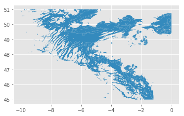

```python
fa.plot()
plt.show()
```

Διαβάζουμε το αρχείο “fishing_interdiction.shp” το οποίο είναι της μορφής shapefile και περιλαμβάνει τις απαγορευμένες περιοχές για ψάρεμα

```python
fi_df = GeoDataFrame.from_file('FishingConstraints/fishing_interdiction.shp').to_crs({'init': 'epsg:4326'})
fi_df['geoid'] = fi_df.index.astype(str)
```

Εδώ βλέπουμε πως το αρχείο με τις απαγορευμένες περιοχές για Αλίευση περιλαμβάνει μονό 2 πολύγωνα

```python
fi_df.head()
```

|  | FID | geometry | geoid |
| --- | --- | --- | --- |
| 0 | 0 | POLYGON ((-3.856234025018865 47.79137985330802... | 0 |
| 1 | 1 | (POLYGON ((-4.629735984460192 48.2805721145554... | 1 |

```python
fi_df.geometry.area
```

```
0    0.007249
1    0.008804
dtype: float64
```

Γίνεται η απεικόνιση των 2 περιοχών αυτών

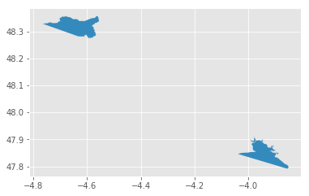

```python
fi_df.plot()
plt.show()
```

Εδω βλέπουμε τις μέγιστες άλλα και τις ελάχιστες τιμές για τα lon και lat των δυο πολυγώνων

```python
fi_df.bounds
```

|  | minx | miny | maxx | maxy |
| --- | --- | --- | --- | --- |
| 0 | -4.038353 | 47.791380 | -3.850586 | 47.909069 |
| 1 | -4.767041 | 48.275037 | -4.554939 | 48.356223 |

Αφού έχουμε πλέον τις τιμές αυτές , οι προσεγγίσεις μας στο πρόβλημα του εντοπισμού πλοίων μέσα στις απαγορευμένες περιοχές για αλίευση θα είναι οι εξής :

- Θα ορίσουμε δυο καινούρια πολύγωνα σε μορφή παραλληλογράμμων στον χώρο, όπου είναι τα δυο πολύγωνα
- Θα ψάξουμε ποια πλοία πέρνανε από αυτά τα καινούρια πολύγωνα μέσω της εντολής Filter του spark </font>

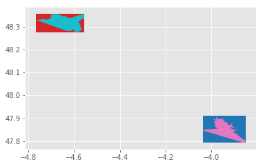

```python
p1 = Polygon([ (-4.038353, 47.909069),(-4.038353,47.791380), (-3.850586, 47.791380 ),(-3.850586,47.909069)])
p2 = Polygon([ (-4.767041,  48.356223),(-4.767041, 48.275037), (-4.554939,48.275037 ),(-4.554939, 48.356223)])
g = gpd.GeoSeries([p1,p2,fi_df['geometry'][0],fi_df['geometry'][1]])
g.plot(cmap='tab10')
```

Διαβάζουμε τα εξής αρχεία μέσω του hdfs :</font >

- nari_dynamic.csv
- ShipTypesList. Csv
- nari_static.csv

```python
df = spark.read.load("hdfs:///user/user/inputs/nari_dynamic.csv",format="csv", sep=",", inferSchema="true", header="true")
ShipTypesList = spark.read.load("hdfs:///user/user/inputs/ShipTypesList.csv",format="csv", sep=",", inferSchema="true", header="true")
nari_static = spark.read.load("hdfs:///user/user/inputs/nari_static.csv",format="csv", sep=",", inferSchema="true", header="true")
```

Εδώ βλέπουμε το σχήμα (στήλες) που έχει το κάθε ένα αρχείο άλλα και μια αναπαράσταση των δεδομένων του κάθε αρχείου

```python
df=df.drop('_c0')
df.printSchema()
df.show()
```

```
root
 |-- sourcemmsi: integer (nullable = true)
 |-- navigationalstatus: double (nullable = true)
 |-- rateofturn: double (nullable = true)
 |-- speedoverground: double (nullable = true)
 |-- courseoverground: double (nullable = true)
 |-- trueheading: integer (nullable = true)
 |-- lon: double (nullable = true)
 |-- lat: double (nullable = true)
 |-- t: integer (nullable = true)

+----------+------------------+----------+---------------+----------------+-----------+-------------------+------------------+----------+
|sourcemmsi|navigationalstatus|rateofturn|speedoverground|courseoverground|trueheading|                lon|               lat|         t|
+----------+------------------+----------+---------------+----------------+-----------+-------------------+------------------+----------+
| 245257000|               0.0|       0.0|            0.1|            13.1|         36|         -4.4657183|48.382490000000004|1443650402|
| 227705102|              15.0|    -127.0|            0.0|           262.7|        511|         -4.4965715|          48.38242|1443650403|
| 228131600|              15.0|    -127.0|            8.5|           263.7|        511|          -4.644325|         48.092247|1443650404|
| 228051000|               0.0|    -127.0|            0.0|           295.0|        511|-4.4851084000000006|          48.38132|1443650405|
| 227574020|              15.0|    -127.0|            0.1|           248.6|        511| -4.495441400000001|          48.38366|1443650406|
| 228854000|              15.0|       0.0|           10.4|           258.2|        259|          -4.347825|         48.117958|1443650408|
| 227415000|              15.0|    -127.0|           11.4|           176.5|        511|         -4.7691517|         47.987152|1443650409|
| 228037700|              15.0|    -127.0|            9.1|            78.5|        511|         -4.4719133|48.166340000000005|1443650411|
| 227443000|              15.0|    -127.0|           11.1|           171.5|        511|-4.7826319999999996|         48.005634|1443650411|
| 245257000|               0.0|       0.0|            0.0|            13.1|         35|           -4.46572|48.382507000000004|1443650413|
| 228051000|               0.0|    -127.0|            0.0|           292.2|        511|         -4.4850984|         48.381313|1443650415|
| 228131600|              15.0|    -127.0|            8.5|           265.2|        511|          -4.644965|          48.09218|1443650416|
| 228854000|              15.0|     127.0|           10.3|           262.7|        270|          -4.348457|         48.117886|1443650417|
| 228037600|              15.0|    -127.0|            9.1|            87.6|        511|         -4.4480133|         48.157574|1443650419|
| 227415000|              15.0|    -127.0|           11.3|           175.8|        511|         -4.7691116|          47.98662|1443650419|
| 227443000|              15.0|    -127.0|           11.3|           172.6|        511|         -4.7825317|48.005115999999994|1443650420|
| 228037700|              15.0|    -127.0|            6.7|            79.3|        511|-4.4714084000000005|           48.1664|1443650421|
| 245257000|               0.0|       0.0|            0.0|            13.1|         35| -4.465721599999999|          48.38252|1443650423|
| 227705102|              15.0|    -127.0|            0.0|           262.3|        511| -4.496573400000001|48.382422999999996|1443650423|
| 228051000|               0.0|    -127.0|            0.0|           291.5|        511|         -4.4850965|          48.38132|1443650424|
+----------+------------------+----------+---------------+----------------+-----------+-------------------+------------------+----------+
only showing top 20 rows
```

```python
df_d=df.describe()
df_d.show()
```

```
+-------+--------------------+------------------+-----------------+------------------+-------------------+--------------------+
|summary|          sourcemmsi|navigationalstatus|  speedoverground|               lon|                lat|                   t|
+-------+--------------------+------------------+-----------------+------------------+-------------------+--------------------+
|  count|            19035630|          18084115|         19035630|          19035630|           19035630|            19035630|
|   mean| 2.551771247438914E8| 6.035147586708003| 8.98630595889961|-4.568561120024541| 48.285813586254896|1.4516568505196023E9|
| stddev|1.1575024337971106E8| 6.825135013024206|21.95265285179425|0.2784973922289842|0.18590166957475818|   4570324.795492887|
|    min|              923166|               0.0|              0.0|         -9.713331|          45.001045|          1443650401|
|    max|           999999999|              15.0|            102.3|      -0.015736667| 50.887634000000006|          1459461599|
+-------+--------------------+------------------+-----------------+------------------+-------------------+--------------------+
```

Παρακάτω βλέπουμε ένα ραβδογραμμα το οποίο περιγράφει την πυκνότητα της ταχύτητας σε όλα το data set

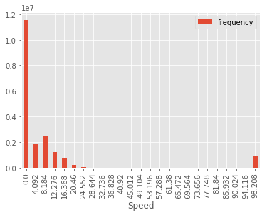

```python
df_hist_speed = df.select('speedoverground').rdd.flatMap(lambda x: x).histogram(25)
pd.DataFrame(
    list(zip(*df_hist_speed)),
    columns=['Speed', 'frequency']
).set_index(
    'Speed'
).plot(kind='bar');
```

```python
ShipTypesList.printSchema()
ShipTypesList.show()
```

```
root
 |-- id_shiptype: integer (nullable = true)
 |-- shiptype_min: integer (nullable = true)
 |-- shiptype_max: integer (nullable = true)
 |-- type_name: string (nullable = true)
 |-- ais_type_summary: string (nullable = true)

+-----------+------------+------------+----------------+-----------------+
|id_shiptype|shiptype_min|shiptype_max|       type_name| ais_type_summary|
+-----------+------------+------------+----------------+-----------------+
|          1|          10|          19|        Reserved|      Unspecified|
|          2|          20|          28|    Wing In Grnd|     Wing in Grnd|
|          3|          29|          29|    SAR Aircraft|Search and Rescue|
|          4|          30|          30|         Fishing|          Fishing|
|          5|          31|          31|             Tug|              Tug|
|          6|          32|          32|             Tug|              Tug|
|          7|          33|          33|         Dredger|    Special Craft|
|          8|          34|          34|     Dive Vessel|    Special Craft|
|          9|          35|          35|    Military Ops|    Special Craft|
|         10|          36|          36|  Sailing Vessel|   Sailing Vessel|
|         11|          37|          37|  Pleasure Craft|   Pleasure Craft|
|         12|          38|          38|        Reserved|      Unspecified|
|         13|          39|          39|        Reserved|      Unspecified|
|         14|          40|          49|High-Speed Craft| High-Speed Craft|
|         15|          50|          50|    Pilot Vessel|    Special Craft|
|         16|          51|          51|             SAR|Search and Rescue|
|         17|          52|          52|             Tug|              Tug|
|         18|          53|          53|     Port Tender|    Special Craft|
|         19|          54|          54|  Anti-Pollution|    Special Craft|
|         20|          55|          55|     Law Enforce|    Special Craft|
+-----------+------------+------------+----------------+-----------------+
only showing top 20 rows
```

```python
ShipTypesList_d=ShipTypesList.describe()
ShipTypesList_d.show()
```

[output not shown]

```python
nari_static.printSchema()
nari_static.sort("sourcemmsi","t").show()
```

```
root
 |-- sourcemmsi: integer (nullable = true)
 |-- imonumber: integer (nullable = true)
 |-- callsign: string (nullable = true)
 |-- shipname: string (nullable = true)
 |-- shiptype: integer (nullable = true)
 |-- tobow: integer (nullable = true)
 |-- tostern: integer (nullable = true)
 |-- tostarboard: integer (nullable = true)
 |-- toport: integer (nullable = true)
 |-- eta: string (nullable = true)
 |-- draught: double (nullable = true)
 |-- destination: string (nullable = true)
 |-- mothershipmmsi: integer (nullable = true)
 |-- t: integer (nullable = true)

+----------+---------+--------+----------+--------+-----+-------+-----------+------+------------+-------+-----------+--------------+----------+
|sourcemmsi|imonumber|callsign|  shipname|shiptype|tobow|tostern|tostarboard|toport|         eta|draught|destination|mothershipmmsi|         t|
+----------+---------+--------+----------+--------+-----+-------+-----------+------+------------+-------+-----------+--------------+----------+
|      1178|        0| F-ZBGD |MARPOL 46 |      54|    0|      0|          0|     0|00-00 24:60 |    0.0|           |          null|1453825433|
|      2383|        0|        |          |      51|    0|      0|          0|     0|00-00 24:60 |    0.0|           |          null|1444742870|
|      2383|        0|        |          |      51|    0|      0|          0|     0|00-00 24:60 |    0.0|           |          null|1444743230|
|      2383|        0|        |          |      51|    0|      0|          0|     0|00-00 24:60 |    0.0|           |          null|1444743231|
|      2383|        0|        |          |      51|    0|      0|          0|     0|00-00 24:60 |    0.0|           |          null|1444743593|
|      2383|        0|        |          |      51|    0|      0|          0|     0|00-00 24:60 |    0.0|           |          null|1444743953|
|      2383|        0|        |          |      51|    0|      0|          0|     0|00-00 24:60 |    0.0|           |          null|1444744671|
|      2383|        0|        |          |      51|    0|      0|          0|     0|00-00 24:60 |    0.0|           |          null|1444745032|
|      2383|        0|        |          |      51|    0|      0|          0|     0|00-00 24:60 |    0.0|           |          null|1444747953|
|      2383|        0|        |          |      51|    0|      0|          0|     0|00-00 24:60 |    0.0|           |          null|1444748582|
|      2383|        0|        |          |      51|    0|      0|          0|     0|00-00 24:60 |    0.0|           |          null|1444749870|
|      2383|        0|        |          |      51|    0|      0|          0|     0|00-00 24:60 |    0.0|           |          null|1444750796|
|      2383|        0|        |          |      51|    0|      0|          0|     0|00-00 24:60 |    0.0|           |          null|1444751659|
|      2383|        0|        |          |      51|    0|      0|          0|     0|00-00 24:60 |    0.0|           |          null|1444752019|
|      2383|        0|        |          |      51|    0|      0|          0|     0|00-00 24:60 |    0.0|           |          null|1444752381|
|      2383|        0|        |          |      51|    0|      0|          0|     0|00-00 24:60 |    0.0|           |          null|1444752741|
|      2383|        0|        |          |      51|    0|      0|          0|     0|00-00 24:60 |    0.0|           |          null|1444753101|
|      2383|        0|        |          |      51|    0|      0|          0|     0|00-00 24:60 |    0.0|           |          null|1444753463|
|      2383|        0|        |          |      51|    0|      0|          0|     0|00-00 24:60 |    0.0|           |          null|1444753823|
|      2383|        0|        |          |      51|    0|      0|          0|     0|00-00 24:60 |    0.0|           |          null|1444810823|
+----------+---------+--------+----------+--------+-----+-------+-----------+------+------------+-------+-----------+--------------+----------+
only showing top 20 rows
```

```python
nari_static_d=nari_static.describe()
nari_static_d.show()
```

```
+-------+-------------------+----------+------------------+
|summary|         sourcemmsi|  shipname|          shiptype|
+-------+-------------------+----------+------------------+
|  count|            1078617|   1078558|           1064192|
|   mean|2.562654786015351E8|      null|50.959855928253546|
| stddev|9.952139465312959E7|      null|  22.3658081929189|
|    min|               1178|          |                 0|
|    max|          999999999|ZUIDVLIET |                99|
+-------+-------------------+----------+------------------+
```

Γίνεται μια επιλογή στηλών οι όποιες θα είναι αυτές που θα χρησιμοποιήσουμε ή θα μας είναι χρήσιμες στην συνέχεια .

```python
df = df.select('sourcemmsi', 'navigationalstatus','speedoverground','lon','lat','t')
ShipTypesList =ShipTypesList.select(col("shiptype_min").alias("shiptype"),'shiptype_max','ais_type_summary')
nari_static =nari_static.select( 'sourcemmsi','shipname','shiptype')
```

```python
print("Το πληθος Των γραμμών στο data set 'nari_dynamic είναι' : " +repr(df.count()))
print("Το πληθος των πλοιων στο data set είναι : " +repr(df.select(df['sourcemmsi']).distinct().count()))
print("Το πληθος Των γραμμών στο data set ShipTypesList είναι : "+ repr(ShipTypesList.count()))
print("Το πληθος Των γραμμών στο data set nari_static είναι : " + repr(nari_static.count()))
```

```
Το πληθος Των γραμμών στο data set 'nari_dynamic είναι' : 19035630
Το πληθος των πλοιων στο data set είναι : 5055
Το πληθος Των γραμμών στο data set ShipTypesList είναι : 38
Το πληθος Των γραμμών στο data set nari_static είναι : 1078617
```

Εκχωρούμε στην μεταβλητή df_mmsi τα μοναδικά mmsi που υπάρχουν σε όλο το data set ώστε να συνεχίσουμε με το join που θα κάνουμε στους δυο πίνακες

```python
df_mmsi=df.select('sourcemmsi').distinct()
```

Παρακάτω γίνεται ένα join των data set df_mmsi και nari_static ώστε να παράγουμε έναν καινούριο πινάκα join_Df με πρώτη στήλη το Mmsi και δεύτερη στήλη το shiptype το οποίο είναι ο τύπος του κάθε πλοίου.

```python
nari_staticc=nari_static.distinct()
joined_df=df_mmsi.join(nari_staticc, ['sourcemmsi'])
join_Df = joined_df.where(joined_df.shiptype.isNotNull()).distinct()
join_Df = join_Df.withColumn('sourcemmsi', col("sourcemmsi").cast(IntegerType()))
join_Df = join_Df.withColumn('shiptype', col("shiptype").cast(IntegerType()))
```

Παρακάτω χρησιμοποιούμε την διαδικασία MapReduce για να εξάγουμε το πλήθος των πλοίων για όλα τα διαφορετικά είδη

```python
start_time = time.time()
a=join_Df.select('shiptype').rdd.map(lambda x: (x,1)).reduceByKey(lambda a,b: a+b)
a.collect()
```

```
[(Row(shiptype=72), 19),
 (Row(shiptype=73), 10),
 (Row(shiptype=74), 33),
 (Row(shiptype=75), 2),
 (Row(shiptype=76), 4),
 (Row(shiptype=77), 4),
 (Row(shiptype=0), 59),
 (Row(shiptype=78), 1),
 (Row(shiptype=79), 309),
 (Row(shiptype=69), 19),
 (Row(shiptype=70), 1551),
 (Row(shiptype=71), 236),
 (Row(shiptype=57), 1),
 (Row(shiptype=60), 42),
 (Row(shiptype=50), 5),
 (Row(shiptype=51), 20),
 (Row(shiptype=52), 39),
 (Row(shiptype=54), 1),
 (Row(shiptype=55), 2),
 (Row(shiptype=40), 2),
 (Row(shiptype=32), 3),
 (Row(shiptype=33), 14),
 (Row(shiptype=34), 2),
 (Row(shiptype=35), 22),
 (Row(shiptype=96), 2),
 (Row(shiptype=97), 1),
 (Row(shiptype=36), 224),
 (Row(shiptype=37), 59),
 (Row(shiptype=99), 17),
 (Row(shiptype=88), 1),
 (Row(shiptype=89), 201),
 (Row(shiptype=90), 75),
 (Row(shiptype=91), 4),
 (Row(shiptype=30), 352),
 (Row(shiptype=31), 5),
 (Row(shiptype=92), 2),
 (Row(shiptype=94), 3),
 (Row(shiptype=95), 1),
 (Row(shiptype=80), 370),
 (Row(shiptype=81), 74),
 (Row(shiptype=20), 2),
 (Row(shiptype=82), 97),
 (Row(shiptype=83), 32),
 (Row(shiptype=84), 38)]
```

```python
print('Ο χρόνος εκτέλεσης της εντολής είναι : ' + repr(time.time() - start_time))
```

```
Ο χρόνος εκτέλεσης της εντολής είναι : 30.40584897994995
```

```python
aDF=a.toDF()
aDF.toPandas().to_csv("count_shiptype_df_inside_df.csv")
```

## Μέρος 2

## Εύρεση πλοίων εντος των απαγορευμένων περιοχών

## Πρώτη απαγορευμένη περιοχή

Δημιουργούμε την συνάρτηση plot1 για διευκόλυνση τον απεικονίσεων που θα κάνουμε για τις δυο περιοχές σε συνδυασμό με τα points [ lon , lat ] των πλοίων που βρίσκονται εντος των περιοχών αυτών

```python
def plot1(df,a,b):
    geometry = [Point(xy) for xy in zip(df.lon, df.lat)]
    newdf_psarema_1 = df.drop(['lon', 'lat'], axis=1)
    crs = {'init': 'epsg:4326'}
    gdf = GeoDataFrame(newdf_psarema_1, crs=crs, geometry=geometry)
    fig, ax = plt.subplots()
    plt.title(b)
    a.plot(ax=ax, facecolor='gray');
    gdf.plot(ax=ax, color='red', markersize=5);
    plt.tight_layout();
```

Εδώ χρησιμοποιούμε έναν μετασχηματισμό ‘Transformations’ όπως λέγετε στο spark την filter() , όπου με αυτή βρίσκουμε τα πλοία που είναι μέσα στο πολύγωνο το οποίο έχουμε δημιουργήσει.Τα αποτελέσματα τα εκχωρούμε στη μεταβλητή df_Entos_fi

```python
df_Entos_fi = df.filter((df["lat"] <=fi_df.bounds['maxy'][1]) & (df["lat"] >= fi_df.bounds['miny'][1]) &\
                 (df["lon"] >= fi_df.bounds['minx'][1]) & (df["lon"] <= fi_df.bounds['maxx'][1]))
```

```python
start_time = time.time()
df_Entos_fi.show()
print('Ο χρόνος εκτέλεσης της εντολής είναι : ' + repr(time.time() - start_time))
```

```
+----------+------------------+---------------+-------------------+------------------+----------+
|sourcemmsi|navigationalstatus|speedoverground|                lon|               lat|         t|
+----------+------------------+---------------+-------------------+------------------+----------+
| 227008170|               0.0|            9.4|          -4.555365|           48.3506|1443672714|
| 227008170|               0.0|            9.2|          -4.556015|         48.350433|1443672725|
| 227008170|               0.0|            9.2|          -4.556565|         48.350315|1443672734|
| 227008170|               0.0|            9.3|          -4.557232|48.350165999999994|1443672745|
| 227008170|               0.0|            9.4|          -4.557915|             48.35|1443672756|
| 227008170|               0.0|            9.4|          -4.558465|         48.349865|1443672764|
| 227008170|               0.0|            9.4|-4.5590150000000005|          48.34975|1443672775|
| 227008170|               0.0|            9.3|          -4.559682|         48.349567|1443672785|
| 227008170|               0.0|            9.2|          -4.560332|48.349334999999996|1443672794|
| 227008170|               0.0|            9.2|          -4.560848|         48.349216|1443672805|
| 227008170|               0.0|            9.2|          -4.561498|          48.34902|1443672816|
| 227008170|               0.0|            9.2|          -4.561965|48.348884999999996|1443672825|
| 227008170|               0.0|            9.3|          -4.562615|48.348682000000004|1443672835|
| 227008170|               0.0|            9.3|-4.5631485000000005|         48.348534|1443672845|
| 227008170|               0.0|            9.3|-4.5637984000000005|          48.34835|1443672855|
| 227008170|               0.0|            9.3| -4.564448400000001|          48.34815|1443672865|
| 227008170|               0.0|            9.3|          -4.564998|48.348015000000004|1443672876|
| 227008170|               0.0|            9.3|          -4.565565|         48.347916|1443672885|
| 227008170|               0.0|            9.4|          -4.566332|          48.34783|1443672896|
| 227008170|               0.0|            9.4|         -4.5669484|         48.347683|1443672905|
+----------+------------------+---------------+-------------------+------------------+----------+
only showing top 20 rows

Ο χρόνος εκτέλεσης της εντολής είναι : 10.66806411743164
```

Στον παρακάτω πινάκα βλέπουμε μερικά περιγραφικά μέτρα του data set nari_dynamic εντος της πρώτης απαγορευμένης περιοχής

```python
start_time = time.time()
df_Entos_fi_d=df_Entos_fi.describe()
df_Entos_fi_d.show()
print('Ο χρόνος εκτέλεσης της εντολής είναι : ' + repr(time.time() - start_time))
```

```
+-------+--------------------+------------------+------------------+------------------+--------------------+-------------------+
|summary|          sourcemmsi|navigationalstatus|   speedoverground|               lon|                 lat|                  t|
+-------+--------------------+------------------+------------------+------------------+--------------------+-------------------+
|  count|             1120332|           1012222|           1120332|           1120332|             1120332|            1120332|
|   mean|2.5322901677436063E8| 4.530944792743094|19.277535230621403|-4.639560669920764|   48.31314135079534|1.451673392044601E9|
| stddev| 9.995868429258256E7| 6.576427849450526|28.631785264985968|0.0585305768228659|0.021470672859597726| 4717799.5428279005|
|    min|           205204000|               0.0|               0.0|          -4.76704|  48.275040000000004|         1443651181|
|    max|           999999999|              15.0|             102.3|          -4.55494|  48.356182000000004|         1459461567|
+-------+--------------------+------------------+------------------+------------------+--------------------+-------------------+

Ο χρόνος εκτέλεσης της εντολής είναι : 26.37974500656128
```

Παρακάτω βλέπουμε ένα ραβδογραμμα το οποίο περιεχεί τις συχνότητες της ταχύτητας που κινούνται τα πλοία μέσα στην πρώτη απαγορευμένη περιοχή

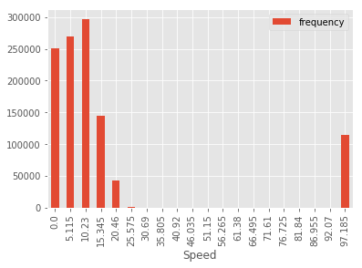

```python
df_Entos_fi_hist_speed = df_Entos_fi.select('speedoverground').rdd.flatMap(lambda x: x).histogram(20)
pd.DataFrame(
    list(zip(*df_Entos_fi_hist_speed)),
    columns=['Speed', 'frequency']
).set_index(
    'Speed'
).plot(kind='bar');
```

Βλέπουμε τα αποτελέσματα που πήραμε από την filter()

```python
print('Το πλήθος τον γραμμών που εντοπίστηκαν μέσα στο καινούριο πολύγωνο είναι : '+repr(df_Entos_fi.count()))
```

```
Το πλήθος τον γραμμών που εντοπίστηκαν μέσα στο καινούριο πολύγωνο είναι : 1120332
```

Εδω υπολογίζετε το πλήθος των μοναδικών mmsi που έχουν βρεθεί εντος περιοχής

```python
df_fi_mmsi=df_Entos_fi.select("sourcemmsi").distinct()
print("Το πλήθος των πλοίων που έχουν βρεθεί στο συγκεκριμένο πολύγωνο είναι : "  +repr(df_fi_mmsi.count()))
```

```
Το πλήθος των πλοίων που έχουν βρεθεί στο συγκεκριμένο πολύγωνο είναι : 474
```

Με την χρήση της εντολής join βρίσκουμε τον τύπο των πλοίων εντος της περιοχής έχοντας χρησιμοποίησει τον πινάκα df_fi_mmsi όπου περιέχει μονό τα mmsi των πλοίων και το data set nari_static το οποίο περιέχει τον τύπο του κάθε mmsi.

```python
joined=df_fi_mmsi.join(nari_static, ['sourcemmsi'])
join_Df1 = joined.where(joined.shiptype.isNotNull()).distinct()
join_Df1 = join_Df1.withColumn('sourcemmsi', col("sourcemmsi").cast(IntegerType()))
join_Df1 = join_Df1.withColumn('shiptype', col("shiptype").cast(IntegerType()))
join_Dfnew=join_Df1.join(ShipTypesList, ['shiptype'])
```

Εδώ μετατραπούμε τα dataframe μας σε rdd και υπολογίζουμε το πλήθος των διαφορετικών τύπων πλοίων εντος της περιοχής με την μέθοδο MapReduce .

```python
start_time = time.time()
a=join_Df1.select('shiptype').rdd.map(lambda x: (x,1)).reduceByKey(lambda a,b: a+b)
a.collect()
```

```
[(Row(shiptype=73), 1),
 (Row(shiptype=74), 1),
 (Row(shiptype=0), 18),
 (Row(shiptype=79), 19),
 (Row(shiptype=69), 4),
 (Row(shiptype=70), 75),
 (Row(shiptype=71), 8),
 (Row(shiptype=57), 1),
 (Row(shiptype=60), 13),
 (Row(shiptype=50), 3),
 (Row(shiptype=51), 7),
 (Row(shiptype=52), 13),
 (Row(shiptype=54), 1),
 (Row(shiptype=55), 2),
 (Row(shiptype=32), 2),
 (Row(shiptype=33), 10),
 (Row(shiptype=34), 1),
 (Row(shiptype=35), 17),
 (Row(shiptype=97), 1),
 (Row(shiptype=36), 118),
 (Row(shiptype=37), 35),
 (Row(shiptype=99), 5),
 (Row(shiptype=88), 1),
 (Row(shiptype=89), 22),
 (Row(shiptype=90), 16),
 (Row(shiptype=30), 61),
 (Row(shiptype=92), 1),
 (Row(shiptype=80), 31),
 (Row(shiptype=81), 6),
 (Row(shiptype=82), 7),
 (Row(shiptype=83), 3),
 (Row(shiptype=84), 4)]
```

```python
print('Ο χρόνος εκτέλεσης της εντολής είναι : ' + repr(time.time() - start_time))
```

```
Ο χρόνος εκτέλεσης της εντολής είναι : 32.373764991760254
```

```python
#a=a.toDF()
#a.toPandas().to_csv('count_shiptype_df_inside_1.csv')
#type(a)
```

Στον πινάκα αυτό βλέπουμε τα mmsi των πλοίων που βρεθήκαν εντος της περιοχής, καθώς και τον τύπο τους .

```python
start_time = time.time()
join_Dfnew.select("sourcemmsi","shipname","ais_type_summary","shiptype").show()
print('Ο χρόνος εκτέλεσης της εντολής είναι : ' + repr(time.time() - start_time))
```

```
+----------+------------------+----------------+--------+
|sourcemmsi|          shipname|ais_type_summary|shiptype|
+----------+------------------+----------------+--------+
| 227312180|F/V MARIE-LOU III |         Fishing|      30|
| 244780246|            BRUNEL|  Sailing Vessel|      36|
| 227566870|            JOANNA|  Sailing Vessel|      36|
| 235034658|          ELLIPTIC|  Sailing Vessel|      36|
| 245257000|     EEMS CARRIER |           Cargo|      70|
| 249993000|    BESIKTAS PERA |          Tanker|      80|
| 205204000|NATO WARSHIP A960 |   Special Craft|      35|
| 227306100|   LA RECOUVRANCE |  Sailing Vessel|      36|
| 276700000|NATO WARSHIP M313 |   Special Craft|      35|
| 311164000|    ATLANTICA HAV |           Cargo|      70|
| 245547000|       ABIS DOVER |           Cargo|      70|
| 227337570|        MAGIC KILI|  Sailing Vessel|      36|
| 228267900|        F/V FELIR |         Fishing|      30|
| 227686540|          EMERAUDE|         Fishing|      30|
| 235003780|          TAMARIND|  Sailing Vessel|      36|
| 269669000|        SCL ANITA |           Cargo|      70|
| 227062780|        BOURRE PIF|   Special Craft|      35|
| 246058000|            SIF R |   Special Craft|      33|
| 265756690|    S/Y TARANTELLA|  Sailing Vessel|      36|
| 311000369|    SKANDI AFRICA |           Cargo|      70|
+----------+------------------+----------------+--------+
only showing top 20 rows

Ο χρόνος εκτέλεσης της εντολής είναι : 20.99481701850891
```

Για την μεταβλητή df_fi_7 :

- Εδώ εντοπίζουμε ποια από το πλοία έχουν στην στήλη navigationalstatus το νούμερο 7 .Εάν ένα πλοίο είναι στην κατάσταση 7 τότε αυτό σημαίνει πως είναι σε κατάσταση αλίευσης, πράγμα το οποίο μας ενδιαφέρει αρκετά στην συγκεκριμένη περιοχή που ψάχνουμε.

Για την μεταβλητή df_fi_ships :

- Στην μεταβλητή αυτή κάνουμε το ίδιο όπως το παραπάνω άλλα με μονή διαφορά ότι υπολογίζουμε και την ταχύτητα του πλοίου ώστε να είμαστε σίγουρη πως αλιεύει στην περιοχή αυτή . Εχουμε ορίσει αυθαίρετα το κατώφλι 2 κόμβους . </font>

```python
df_fi_7=df_Entos_fi.filter(df_Entos_fi['navigationalstatus']==7)
df_fi_ships=df_Entos_fi.filter(( df_Entos_fi['navigationalstatus']==7 ) & ( df_Entos_fi['speedoverground'] < 2 ))
```

```python
print("'Το πλήθος τον γραμμών που εντοπίστηκαν μέσα στο  πολύγωνο με navigationalstatus = 7 ειναι : "  +repr(df_fi_7.count()))
print("και το πλήθος των πλοίων είναι :  "  +repr(df_fi_7.select("sourcemmsi").distinct().count()))
```

```
'Το πλήθος τον γραμμών που εντοπίστηκαν μέσα στο  πολύγωνο με navigationalstatus = 7 ειναι : 14384
και το πλήθος των πλοίων είναι :  9
```

```python
print("Το πλήθος τον γραμμών που εντοπίστηκαν μέσα στο πολύγωνο με (navigationalstatus = 7 και speedoverground < 2) ειναι  : "  +repr(df_fi_ships.count()))
print("και το πλήθος των πλοίων είναι :  "  +repr(df_fi_ships.select("sourcemmsi").distinct().count()))
```

```
Το πλήθος τον γραμμών που εντοπίστηκαν μέσα στο πολύγωνο με (navigationalstatus = 7 και speedoverground < 2) ειναι  : 1657
και το πλήθος των πλοίων είναι :  1
```

Καταχωρούμε στις μεταβλητές mmsi_df_fi_ships και mmsi_df_fi_ships_7 τα mmsi των πλοίων τα όποια εντοπιστήκαν εντος του πολυγώνου που δημιουργήσαμε και για της δυο περίπτωσης της όποιες ορίσαμε προηγούμενος

```python
mmsi_df_fi_ships=df_fi_ships.select("sourcemmsi").distinct()
mmsi_df_fi_ships_7=df_fi_7.select("sourcemmsi").distinct()
```

Στο παρακάτω πινάκα εμφανίζετε το μοναδικό πλοίο το οποίο εντοπιστηκέ εντος της απαγορευμένης περιοχής με navigationalstatus=7 και η ταχύτητα του να μην ξεπερνά τους 2 κόμβους .

```python
start_time = time.time()
mmsi_df_fi_ships.join(join_Df1, ['sourcemmsi']).distinct().show()
print('Ο χρόνος εκτέλεσης της εντολής είναι : ' + repr(time.time() - start_time))
```

```
+----------+-----------+--------+
|sourcemmsi|   shipname|shiptype|
+----------+-----------+--------+
| 228827000|F/V.OCEANE |      30|
+----------+-----------+--------+

Ο χρόνος εκτέλεσης της εντολής είναι : 56.323527812957764
```

Στο παρακάτω πινάκα εμφανιζονται τα πλοία τα οποία εντοπιστήκαν εντος της απαγορευμένης περιοχής με navigationalstatus=7 .

```python
start_time = time.time()
mmsi_df_fi_ships_7.join(join_Df1, ['sourcemmsi']).distinct().show()
print('Ο χρόνος εκτέλεσης της εντολής είναι : ' + repr(time.time() - start_time))
```

```
+----------+-------------------+--------+
|sourcemmsi|           shipname|shiptype|
+----------+-------------------+--------+
| 227867000|  F/V KREIZ AR MOR |      30|
| 227391000|        F/V EFFERA |      30|
| 226084000|        F/V KADEGE |      30|
| 227392000|          F/V ALYA |      90|
| 228827000|        F/V.OCEANE |      30|
| 227347000|        F/V IROISE |      30|
| 226216000| FV DAMIEN FLORENT |      30|
| 227577000|        F/V JUDINE |      30|
| 227091000|COTES DE LA MANCHE |      90|
+----------+-------------------+--------+

Ο χρόνος εκτέλεσης της εντολής είναι : 44.01289105415344
```

Μετατραπούμε τα δεδομένα όπου είχαμε ως αποτελέσματα προηγουμένως από Spark.DataFrame σε μορφή DataFrame το οποίο υποστηρίζει η βιβλιοθήκη Pandas ώστε να απεικονίσουμε τα δεδομένα μας αργότερα </font >

```python
start_time = time.time()
df_fi_ships=df_fi_ships.toPandas()
df_fi_7=df_fi_7.toPandas()
df_Entos_fi=df_Entos_fi.toPandas()
print('Ο χρόνος εκτέλεσης της εντολής είναι : ' + repr(time.time() - start_time))
```

```
Ο χρόνος εκτέλεσης της εντολής είναι : 53.65775394439697
```

Παρακάτω βλέπουμε τα δεδομένα μας εντος της περιοχής που ψάχνουμε αντίστοιχα με τις περιπτώσεις που πήραμε προηγουμένως, καθώς και ένα Plot το οποίο περιχεί όλα τα πλοία τα όποια εντοπίσαμε στην περιοχή αυτήν.

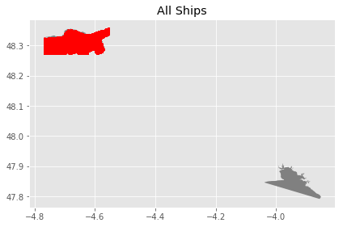

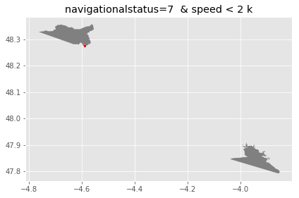

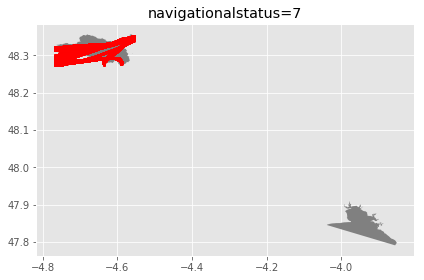

```python
start_time = time.time()
plot1(df_Entos_fi,fi_df,'All Ships')
plot1(df_fi_ships,fi_df,'navigationalstatus=7  & speed < 2 k')
plot1(df_fi_7,fi_df,'navigationalstatus=7')
print('Ο χρόνος εκτέλεσης της εντολής είναι : ' + repr(time.time() - start_time))
```

Η Συνάρτηση plot_mmsi έχει ως σκοπό να της δώσουμε τα δεδομένα πλοίων τα οποία έχουμε εντος της περιοχής καθώς και όλο το DataFrame μας , ώστε για κάθε mmsi που της δίνουμε να μας κάνει μια απεικόνιση των στιγμάτων που αφήνει κάθε πλοίο στων χώρο με βασική ιδέα να έχουμε 30 πριν και μετά από την ώρα που το εντοπίσαμε

```python
def plot_mmsi(df,df_Entos,mmsi) :
    plot_mmsi=df.filter((df['sourcemmsi']==mmsi) & (df['t']>=df_Entos.filter(df_Entos['sourcemmsi']==mmsi).agg({"t": "min"}).collect()[0][0]-1800) & (df['t']<= df_Entos.filter(df_Entos['sourcemmsi']==mmsi).agg({"t": "max"}).collect()[0][0]+1800))
    plot_mmsi=plot_mmsi.toPandas()
    plot1(plot_mmsi,fi_df,'')
```

Γίνεται μια απεικόνιση τριών από εννεά πλοίων οπού κρίναμε σωστά για την περιγραφή και την ανάλυση τους καλώντας την συνάρτηση plot_mmsi

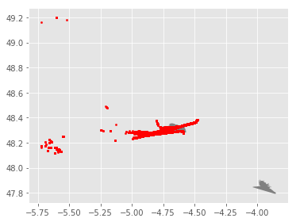

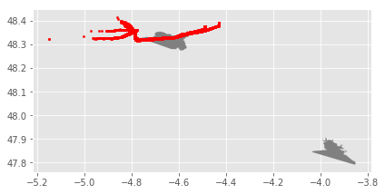

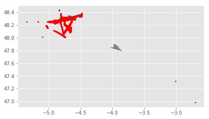

```python
plot_mmsi(df,df_Entos_fi,228827000)
plot_mmsi(df,df_Entos_fi,226084000)
plot_mmsi(df,df_Entos_fi, 227091000)
```

Η συνάρτηση plot_mmsi_Fishing εντοπίζει τις περιοχές στις οποίες αλιευτικά είναι σε κατάσταση αλίευσης διότι η ταχύτητα τους είναι μικρότερη από δυο κόμβους

```python
def plot_mmsi_Fishing(df,df_Entos,mmsi) :
    plot_mmsi=df.filter((df['sourcemmsi']==mmsi))
    plot_mmsi=plot_mmsi.filter(plot_mmsi['speedoverground']<2)
    plot_mmsi=plot_mmsi.toPandas()
    plot1(plot_mmsi,fi_df,'')
```

[figure not shown]

[figure not shown]

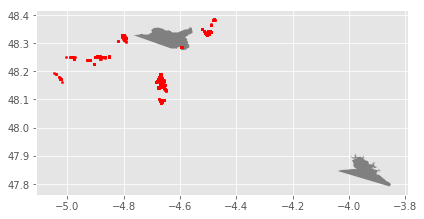

[figure not shown]

[figure not shown]

[figure not shown]

[figure not shown]

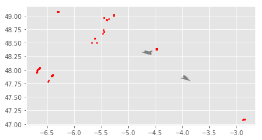

```python
plot_mmsi_Fishing(df,df_Entos_fi,228827000)
plot_mmsi_Fishing(df,df_Entos_fi,226084000)
plot_mmsi_Fishing(df,df_Entos_fi, 227091000)
plot_mmsi_Fishing(df,df_Entos_fi, 227867000)
plot_mmsi_Fishing(df,df_Entos_fi, 227392000)
plot_mmsi_Fishing(df,df_Entos_fi, 227347000)
plot_mmsi_Fishing(df,df_Entos_fi, 226216000)
plot_mmsi_Fishing(df,df_Entos_fi, 227577000)
```

## Δεύτερη απαγορευμένη περιοχή

Βρίσκουμε τα πλοία που είναι μέσα στο δεύτερο πολύγωνο το οποίο έχουμε δημιουργήσει.Τα αποτελέσματα τα εκχωρούμε στη μεταβλητή df_Entos_fi_0

```python
df_Entos_fi_0 = df.filter((df["lat"] <=fi_df.bounds['maxy'][0]) & (df["lat"] >= fi_df.bounds['miny'][0]) &\
                 (df["lon"] >= fi_df.bounds['minx'][0]) & (df["lon"] <= fi_df.bounds['maxx'][0]))
```

```python
df_Entos_fi_0.show()
```

```
+----------+------------------+---------------+-------------------+------------------+----------+
|sourcemmsi|navigationalstatus|speedoverground|                lon|               lat|         t|
+----------+------------------+---------------+-------------------+------------------+----------+
| 228167900|              15.0|            9.6|         -3.9549034|47.809740000000005|1453663869|
| 228167900|              15.0|            9.6|-3.9531467000000005|47.813126000000004|1453663952|
| 228167900|              15.0|            9.5|-3.9523599999999997|         47.814716|1453663990|
| 227306100|               1.0|            0.4|         -3.9489434|          47.88162|1443653640|
| 228037900|               5.0|            0.3|          -3.966355|          47.86488|1443656603|
| 228037900|               5.0|            0.3|         -3.9662933|          47.86483|1443660202|
| 228037900|               5.0|            0.3|         -3.9663067|         47.864914|1443661101|
| 227857000|              15.0|            9.2|-3.9348834000000004|47.845634000000004|1443661128|
| 228037900|               5.0|            0.1|          -3.966305|         47.865097|1443663797|
| 228037900|               5.0|            0.1|-3.9662699999999997|          47.86515|1443664704|
| 227306100|               1.0|            0.3|-3.9484334000000003|         47.881718|1443667139|
| 228037900|               5.0|            0.3|-3.9662800000000002|         47.864902|1443668301|
| 228037900|               5.0|            0.2|-3.9662415999999996|          47.86484|1443671003|
| 228037900|               5.0|            0.5|-3.9662232000000004|          47.86483|1443671903|
| 228037900|               5.0|            0.2|-3.9662132000000003|         47.864834|1443674602|
| 227895000|               0.0|            4.3|          -3.971165|            47.801|1443674894|
| 227895000|               0.0|            4.0|          -3.971165|            47.801|1443674901|
| 227895000|               0.0|            3.9|          -3.971165|         47.801167|1443674903|
| 227895000|               0.0|            3.8|          -3.971165|         47.801167|1443674907|
| 227895000|               0.0|            3.8|          -3.971165|         47.801167|1443674911|
+----------+------------------+---------------+-------------------+------------------+----------+
only showing top 20 rows
```

Παρουσιάζουμε μερικά περιγραφικά μέτρα των δεδομένων μας .

```python
df_Entos_fi_0_d=df_Entos_fi_0.describe()
df_Entos_fi_0_d.show()
```

```
+-------+--------------------+------------------+-----------------+-------------------+--------------------+-------------------+
|summary|          sourcemmsi|navigationalstatus|  speedoverground|                lon|                 lat|                  t|
+-------+--------------------+------------------+-----------------+-------------------+--------------------+-------------------+
|  count|                5300|              4663|             5300|               5300|                5300|               5300|
|   mean|2.2915099013698113E8| 9.788548144971049|6.550415094339629|-3.9481803897547207|   47.83532737830194|1.453776994846415E9|
| stddev|   5860512.264012891| 6.907452010684565|3.974003774361546|0.02852466354202299|0.024807102754329673|  4583915.890535743|
|    min|           211232180|               0.0|              0.0|           -4.03829|           47.791393|         1443653640|
|    max|           319064400|              15.0|             25.2|-3.8545084000000003|  47.900771999999996|         1459461224|
+-------+--------------------+------------------+-----------------+-------------------+--------------------+-------------------+
```

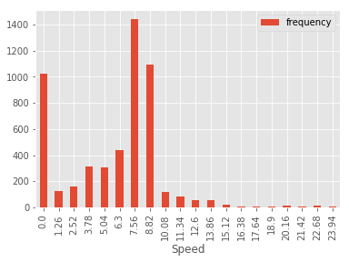

```python
df_Entos_fi_0_hist_speed = df_Entos_fi_0.select('speedoverground').rdd.flatMap(lambda x: x).histogram(20)
pd.DataFrame(
    list(zip(*df_Entos_fi_0_hist_speed)),
    columns=['Speed', 'frequency']
).set_index(
    'Speed'
).plot(kind='bar');
```

```python
print('Το πλήθος τον γραμμών που εντοπίστηκαν μέσα στο καινούριο πολύγωνο είναι : '+repr(df_Entos_fi_0.count()))
```

```
Το πλήθος τον γραμμών που εντοπίστηκαν μέσα στο καινούριο πολύγωνο είναι : 5300
```

Εδω υπολογίζετε το πλήθος των μοναδικών mmsi που έχουν βρεθεί εντος περιοχής

```python
df_fi_mmsi_0=df_Entos_fi_0.select("sourcemmsi").distinct()
print("Το πλήθος των πλοίων που έχουν βρεθεί στο συγκεκριμένο πολύγωνο είναι : "  +repr(df_fi_mmsi_0.count()))
```

```
Το πλήθος των πλοίων που έχουν βρεθεί στο συγκεκριμένο πολύγωνο είναι : 116
```

Με την χρήση της εντολής join βρίσκουμε των τύπο των πλοίων εντος της περιοχής έχοντας χρησιμοποιήσει τον πινάκα df_fi_mmsi_0 όπου περιέχει μονό τα mmsi των πλοίων και το data set nari_static το οποίο περιέχει των τύπο το κάθε mmsi.

```python
joined=df_fi_mmsi_0.join(nari_static, ['sourcemmsi'])
join_Df0 = joined.where(joined.shiptype.isNotNull()).distinct()
join_Df0 = join_Df0.withColumn('sourcemmsi', col("sourcemmsi").cast(IntegerType()))
join_Df0 = join_Df0.withColumn('shiptype', col("shiptype").cast(IntegerType()))
join_Df0new=join_Df0.join(ShipTypesList, ['shiptype'])
```

Εδώ μετατραπούμε τα dataframe μας σε rdd και υπολογίζουμε το πλήθος των διαφορετικών τύπων πλοίων εντος της περιοχής με την μέθοδο MapReduce .

```python
a0=join_Df0.select('shiptype').rdd.map(lambda x: (x,1)).reduceByKey(lambda a,b: a+b)
a0.collect()
```

```
[(Row(shiptype=0), 3),
 (Row(shiptype=70), 1),
 (Row(shiptype=60), 4),
 (Row(shiptype=51), 1),
 (Row(shiptype=52), 2),
 (Row(shiptype=33), 2),
 (Row(shiptype=35), 1),
 (Row(shiptype=36), 34),
 (Row(shiptype=37), 8),
 (Row(shiptype=99), 2),
 (Row(shiptype=90), 3),
 (Row(shiptype=30), 28),
 (Row(shiptype=92), 1)]
```

```python
#a0=a0.toDF()
#a0.toPandas().to_csv('count_shiptype_df_inside_0.csv')
```

Στον πινάκα αυτό βλέπουμε τα mmsi τον πλοίων που βρεθήκαν εντος της περιοχής, καθώς και τον τύπο τους .

```python
join_Df0new.select("sourcemmsi","shipname","ais_type_summary","shiptype").show()
```

```
+----------+-------------------+----------------+--------+
|sourcemmsi|           shipname|ais_type_summary|shiptype|
+----------+-------------------+----------------+--------+
| 228240800|F/V MAILYS CHARLIE |         Fishing|      30|
| 227306100|    LA RECOUVRANCE |  Sailing Vessel|      36|
| 227798280|          JASLAND 2|  Pleasure Craft|      37|
| 211232180|               IZAR|  Sailing Vessel|      36|
| 235081443|   OC23 SOLO SAILOR|  Sailing Vessel|      36|
| 235081443|ARTEMIS23 SOLOBAKER|  Sailing Vessel|      36|
| 227962000|           ALIXEL 2|         Fishing|      30|
| 228387000|     F/V LIBERTY-S |         Fishing|      30|
| 227567680|             PERZEL|         Fishing|      30|
| 228218000|             FRUGY |         Fishing|      30|
| 228762000|    FRENCH WARSHIP |   Special Craft|      35|
| 227570000|       F/V IBARDIN |         Fishing|      30|
| 227191950|   INITIATIVES SOLO|  Sailing Vessel|      36|
| 228066900|            GEVRED |         Fishing|      30|
| 246774000|       EN AVANT 10 |             Tug|      52|
| 228065900| BANQUE POPULAIRE 8|  Sailing Vessel|      36|
| 227383920|          EXCALIBUR|  Sailing Vessel|      36|
| 227548120|             CYRANO|  Sailing Vessel|      36|
| 227688950|              PECAB|  Sailing Vessel|      36|
| 227701720|         FOXY F EWE|  Sailing Vessel|      36|
+----------+-------------------+----------------+--------+
only showing top 20 rows
```

Με βάση τον παραπάνω πινάκα , πήραμε μονό τα πλοία τα όποια ο τύπος τους είναι Fishing

```python
join_Df0new.filter(join_Df0new['ais_type_summary']=='Fishing').show()
```

```
+--------+----------+--------------------+------------+----------------+
|shiptype|sourcemmsi|            shipname|shiptype_max|ais_type_summary|
+--------+----------+--------------------+------------+----------------+
|      30| 228240800| F/V MAILYS CHARLIE |          30|         Fishing|
|      30| 227962000|            ALIXEL 2|          30|         Fishing|
|      30| 228387000|      F/V LIBERTY-S |          30|         Fishing|
|      30| 227567680|              PERZEL|          30|         Fishing|
|      30| 228218000|              FRUGY |          30|         Fishing|
|      30| 227570000|        F/V IBARDIN |          30|         Fishing|
|      30| 228066900|             GEVRED |          30|         Fishing|
|      30| 227474000|       F/V KERFLOUS |          30|         Fishing|
|      30| 228238600|       F/V SANAGA 2 |          30|         Fishing|
|      30| 227984000|        F/V MORGANE |          30|         Fishing|
|      30| 228042600|      F/V MABON III |          30|         Fishing|
|      30| 228126000|      F/V L OCARINA |          30|         Fishing|
|      30| 228247700|        KREIZ AN AOD|          30|         Fishing|
|      30| 228240900|         F/V ZEPHYR |          30|         Fishing|
|      30| 228301700|       F/V ROSSOREN |          30|         Fishing|
|      30| 228020600|         F/V BESAME |          30|         Fishing|
|      30| 228208800|          F/V LYCIA |          30|         Fishing|
|      30| 228206600|JEAN CLAUDE COULO...|          30|         Fishing|
|      30| 228941000|       LE LAURABRENN|          30|         Fishing|
|      30| 228208700|     F/V VAG A LAMM |          30|         Fishing|
+--------+----------+--------------------+------------+----------------+
only showing top 20 rows
```

Ακριβώς με την ίδια λογική όπως και προηγουμένως υπολογίζουμε τις μεταβλητές df_fi_7_0 και df_fi_ships_0

```python
df_fi_7_0=df_Entos_fi_0.filter(df_Entos_fi_0['navigationalstatus']==7)
df_fi_ships_0=df_Entos_fi_0.filter(( df_Entos_fi_0['navigationalstatus']==7 ) & ( df_Entos_fi_0['speedoverground']<= 2 ))
```

```python
print("'Το πλήθος τον γραμμών που εντοπίστηκαν μέσα στο  πολύγωνο με navigationalstatus = 7 ειναι : "  +repr(df_fi_7_0.count()))
print("και το πλήθος των πλοίων είναι :  "  +repr(df_fi_7_0.select("sourcemmsi").distinct().count()))
```

[output not shown]

```python
print("Το πλήθος των γραμμών που εντοπίστηκαν μέσα στο πολύγωνο με (navigationalstatus = 7 και speedoverground <= 2) ειναι  : "  +repr(df_fi_ships_0.count()))
print("και το πλήθος των πλοίων είναι :  "  +repr(df_fi_ships_0.select("sourcemmsi").distinct().count()))
```

```
Το πλήθος τον γραμμών που εντοπίστηκαν μέσα στο πολύγωνο με (navigationalstatus = 7 και speedoverground <= 2) ειναι  : 0
και το πλήθος των πλοίων είναι :  0
```

Καταχωρούμε στις μεταβλητές mmsi_df_fi_ships_0 και mmsi_df_fi_ships_7_0 τα mmsi των πλοίων τα όποια εντοπιστήκαν εντος του πολυγώνου που δημιουργήσαμε και για τις δυο περίπτωσεις τις όποιες ορίσαμε προηγουμένως .

```python
mmsi_df_fi_ships_0=df_fi_ships_0.select("sourcemmsi").distinct()
mmsi_df_fi_ships_7_0=df_fi_7_0.select("sourcemmsi").distinct()
```

Παρατηρούμε ότι στην περίπτωση navigationalstatus = 7 και speedoverground <= 2 δεν βρέθηκε κανένα αλιευτικό πλοίο με τις συνθήκες αυτές .

```python
mmsi_df_fi_ships_0.join(join_Df0, ['sourcemmsi']).distinct().show()
```

```
+----------+--------+--------+
|sourcemmsi|shipname|shiptype|
+----------+--------+--------+
+----------+--------+--------+
```

Στο παρακάτω πινάκα εμφανιζονται τα πλοία τα οποία εντοπιστήκαν εντος της απαγορευμένης περιοχής με navigationalstatus=7 .

```python
mmsi_df_fi_ships_7_0.join(join_Df0, ['sourcemmsi']).distinct().show()
```

```
+----------+--------------+--------+
|sourcemmsi|      shipname|shiptype|
+----------+--------------+--------+
| 227474000| F/V KERFLOUS |      30|
| 228042600|F/V MABON III |      30|
| 228126000|F/V L OCARINA |      30|
| 228910000|F/V L OKEANOS |      90|
| 228355800|  F/V LUANTSA |      30|
+----------+--------------+--------+
```

Μετατραπούμε τα δεδομένα από Spark.DataFrame σε μορφή DataFrame το οποίο υποστηρίζει η βιβλιοθήκη Pandas.

```python
df_fi_ships_0=df_fi_ships_0.toPandas()
df_fi_7_0=df_fi_7_0.toPandas()
df_Entos_fi_0=df_Entos_fi_0.toPandas()
```

Παρακάτω γίνετε μια απεικόνιση των δεδομένων που έχουμε στην μια περίπτωση όπου ήταν επιτυχής το query μας ,καθώς και ένα Plot το οποίο περιχεί όλα τα πλοία τα όποια εντοπίσαμε στην περιοχή αυτήν.

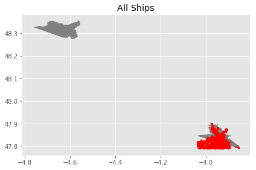

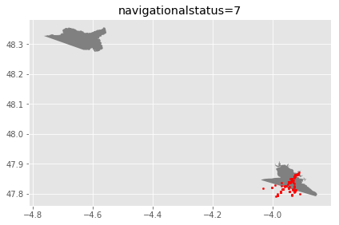

```python
#plot1(df_fi_ships_0,fi_df,'navigationalstatus=7  & speed < 2 k')
plot1(df_Entos_fi_0,fi_df,'All Ships')
plot1(df_fi_7_0,fi_df,'navigationalstatus=7')
```

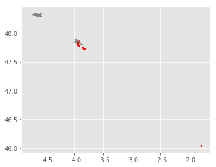

[figure not shown]

[figure not shown]

[figure not shown]

```python
plot_mmsi(df,df_Entos_fi_0,228355800)
plot_mmsi(df,df_Entos_fi_0,228042600)
plot_mmsi(df,df_Entos_fi_0,227474000)
plot_mmsi(df,df_Entos_fi_0,228910000)
```

[figure not shown]

[figure not shown]

[figure not shown]

[figure not shown]

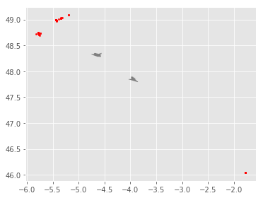

```python
plot_mmsi_Fishing(df,df_Entos_fi_0,227474000)
plot_mmsi_Fishing(df,df_Entos_fi_0,228042600)
plot_mmsi_Fishing(df,df_Entos_fi_0, 228126000)
plot_mmsi_Fishing(df,df_Entos_fi_0,228355800)
```

## Μέρος 3

## Evaluation

Αφού πλέον έχουμε μειώσει των όγκο των δεδομένων μπορούμε να χρησιμοποιήσουμε την συνάρτηση Within η οποία εντοπίζει Points εντος του πολυγώνου που ορίζουμε . Για τον λόγο αυτόν φτιαχτούμε μια συνάρτηση within1 όπου αυτό που κάνει είναι ,μόλις την καλέσουμε να μετατρέψει στην σωστή μορφή τα δεδομένα μας ώστε να τα δεχτεί η συνάρτηση Within

```python
def within1(df, poly,i):
    geometry = [Point(xy) for xy in zip(df.lon, df.lat)]
    newdf = df.drop(['lon', 'lat'], axis=1)
    gdf = GeoDataFrame(newdf, crs={'init': 'epsg:4326'}, geometry=geometry)
    return(df[gdf.within(fi_df.loc[i, 'geometry'])])
```

Εκχωρούμε στην μεταβλητή c τα αποτελέσματα που περνούμε από την συνάρτηση within1

```python
start_time = time.time()
c=within1(df_Entos_fi,fi_df,1)
print('Το πλήθος των πραγματικών γραμμών εντος του πρώτου πολυγώνου είναι : ' +repr(c.sourcemmsi.count()))
print('Ο χρόνος εκτέλεσης της εντολής είναι : ' + repr(time.time() - start_time))
```

```
Το πλήθος των πραγματικών γραμμών εντος του πρώτου πολυγώνου είναι : 908915
Ο χρόνος εκτέλεσης της εντολής είναι : 2085.5904788970947
```

```python
print('Το πλήθος των πλοίων που έχουν βρεθεί στο συγκεκριμένο πολύγωνο είναι :' + repr(len(np.unique(c["sourcemmsi"]))))
```

```
Το πλήθος των πλοίων που έχουν βρεθεί στο συγκεκριμένο πολύγωνο είναι :439
```

Εκχωρούμε στην μεταβλητή d τα αποτελέσματα που περνούμε από την συνάρτηση within1

```python
df_Entos_fi_0=df_Entos_fi_0.toPandas()
start_time = time.time()
d=within1(df_Entos_fi_0,fi_df,0)
print('Το πλήθος των πραγματικών γραμμών εντος του δεύτερου πολυγώνου είναι :' +repr(d.sourcemmsi.count()))
print('Ο χρόνος εκτέλεσης της εντολής είναι : ' + repr(time.time() - start_time))
```

```
Το πλήθος των πραγματικών γραμμών εντος του δεύτερου πολυγώνου είναι :3490
Ο χρόνος εκτέλεσης της εντολής είναι : 6.054187059402466
```

```python
print('Το πλήθος των πλοίων που έχουν βρεθεί στο συγκεκριμένο πολύγωνο είναι :' + repr(len(np.unique(d["sourcemmsi"]))))
```

```
Το πλήθος των πλοίων που έχουν βρεθεί στο συγκεκριμένο πολύγωνο είναι :92
```